# The World's Food Supply is Made Insecure by Climate Change | United Nations

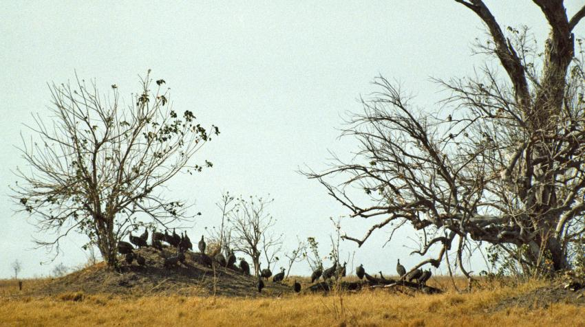

# The World's Food Supply is Made Insecure by Climate Change

*This is the first article of the UNAI 'Food Security and Climate Change' series. Schools and departments which specialise in climate change and food security at UNAI member institutions were asked to submit articles highlighting research and work encompassing the newly adopted Sustainable Development Goals and to showcase the importance of sustainable agriculture to mitigate the dangerous effects of climate change, whilst ensuring present and future food security. Please note that the articles are for discussion, and do not necessarily reflect the views of the United Nations.*

In the next 30 years, food supply and food security will be severely threatened if little or no action is taken to address climate change and the food system's vulnerability to climate change. According to the Intergovernmental Panel on Climate Change (IPCC), the extent of climate change impacts on individual regions will vary over time, and different societal and environmental systems will have varied abilities to mitigate or adapt to change. Negative effects of climate change include the continued rise of global temperatures, changes in precipitation patterns, an increased frequency of droughts and heatwaves, sea-level rise, melting of sea ice and a higher risk of more intense natural disasters.

The IPCC states, Taken as a whole, the range of published evidence indicates that the net damage costs of climate change are likely to be significant and to increase over time.

Future projections in global yield trends of both maize and wheat indicate a significant decline; these declines can be attributed to the negative impacts of climate change arising from increasing greenhouse gas emissions. In many parts of less developed countries in Africa and Central America, maize is a key component in the daily diet and plays a key role in achieving food security in those areas, with nearly 950 million metric tonnes consumed annually. Wheat also plays a central role in diets. With nearly 700 million metric tonnes consumed annually on a global basis, wheat alone provides over 20 per cent of the world's calories and protein. To ensure food security for the predicted population of 9.6 billion people by 2050 the FAO predicts that food production must increase by at least 60 per cent to meet the demand, and a report from [Tilman *et al.*](http://www.pnas.org/content/108/50/20260) in 2011 projected that food production must increase by 100 per cent to meet the projected food demand. With yields declining, and demand for both the amount and quality of food increasing (due to increased disposable income amongst developing countries) intervention is a must.

The negative effects from climate change will cause changes in global weather patterns and cycles that will be both unpredictable and long term. It is foreseen that the fishing industry will also experience significant disruption, with salt water and fresh water fishing at risk. This situation implies a great urgency, as the children who are born in today's world will not have reached graduation age before these problems will have materialized, unless immediate action is taken. We have already seen climate effects on yields in a number of areas, including Europe and southern Asia, since the last IPCC Assessment Report in 2007. Unfortunately, it is the populations in many tropical areas and the southern parts of Europe and North Africa who will pay a great price. These population groups - especially the poor - are the most vulnerable in terms of failing harvests, higher prices and malnutrition in the near future. This multi-faceted crisis will only increase pressure in other areas of the world to increase production, whilst basic living conditions in deprived areas further decrease.

We have to learn how we can adapt the food supply system at a global and regional level in a relatively short amount of time, whilst at the same time, reducing greenhouse gas emissions and our impact upon the environment.

Countries in the Northern Hemisphere, especially Scandinavian countries, are currently experiencing some positive effects from climate change in terms of crop yields. This is due partly to the CO<sub>2</sub>fertilisation effect where increased amounts of carbon dioxide in the atmosphere aid plant growth, but mostly because low levels of warming extend the growth duration of mainly perennial crops such as grass pastures, but reduce the duration of the staple annual crops, such as wheat, maize and rice. However, these effects are not permanent and will not balance the global negative effects of climate change. There is no doubt in the evidence and conclusions of more than 1,000 global and regional studies, that a temperature rise of 1 to 2 degrees Celsius will generally mean a loss in yield of a number of crop varieties, both in the tropical and the temperate regions. An increase of 3 to 4 degrees later on in this century will have very severe consequences for global food security and supply. However, it is remarkable to see that the rice plant is coping a lot better with the changes than other crops.

We need to combat the negative impacts of climate change on food security in many different ways: by decreasing greenhouse emissions to reduce the climate change that will occur; improving the resilience of the global food system to climate change; and developing early warning systems that can warn us in due time when nature is about to 'run wild'.

*Professor John Roy Porter is a professor of agriculture and climate change at the University of Greenwich, England. He is an internationally known scientist in crop ecology and physiology, biological modelling, and agricultural ecology who has received international awards for his research and teaching. He is a coordinating lead author for the IPCC Fifth Assessment Report for the topic of food production and food security, an elected member of the Scientific Advisory Board of the EU Joint Programme Initiative on Agriculture, and Food Security and Climate and Chief Editor of the European Journal of Agronomy.*

References:

Tilman D, Balzer C, Hill J, Befort BL (2011). [Global food demand and the sustainable intensification of agriculture](http://www.pnas.org/content/108/50/20260). *PNAS*, **108**(50) pp. 20260-64.